# AAE722 Assignment 3

## **1. Here we explore the maximal margin classifier using the data set listed in the table below, which has 7 observations in 2 dimensions that belong to two classes.**

### **(1) (4 pts) Sketch the optimal separating hyperplane in the figure below and provide the equation for this hyperplane in the form of β0 + β1X1 + β2X2 = 0.**

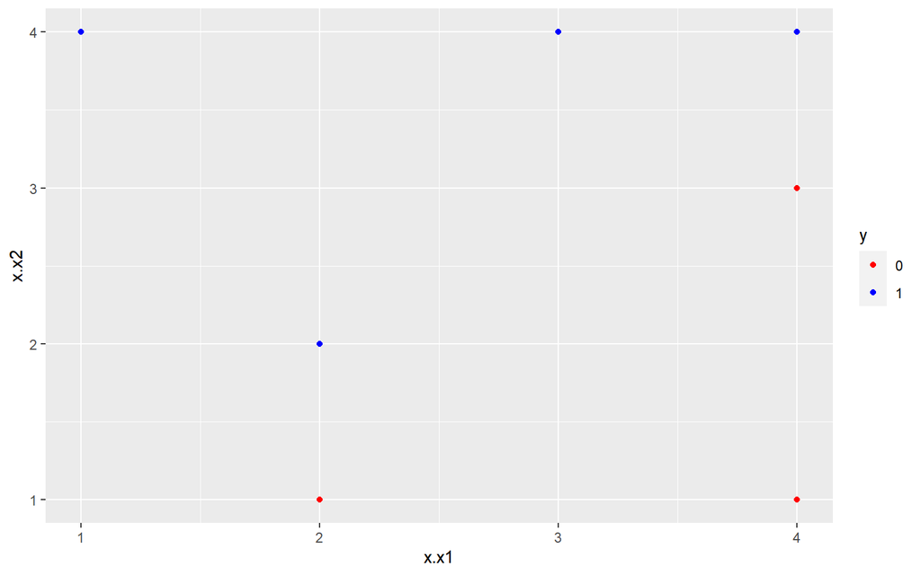

```r
x1 <- c(3,2,4,1,2,4,4)
x2 <- c(4,2,4,4,1,3,1)
target <- c(1,1,1,1,0,0,0)

dat <- data.frame(x=cbind(x2,x1), y=as.factor(target))
ggplot(data = dat, aes(x = x.x1, y = x.x2, color = y)) +
    geom_point() + scale_color_manual(values = c("red", "blue"))
```

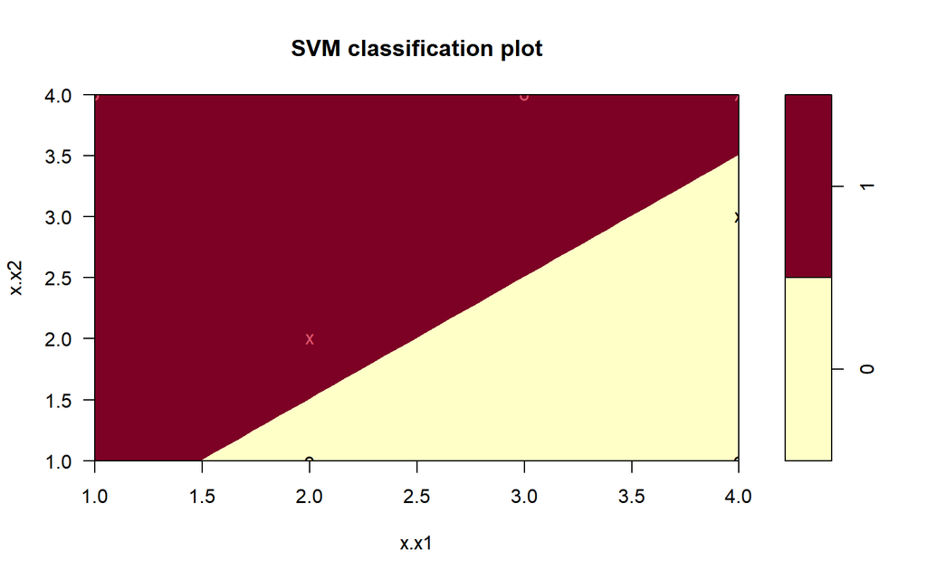

```r
svmfit <- svm(y~., data=dat, kernel="linear", cost=10, scale=FALSE)
plot(svmfit, dat)
```

The equation for this hyperplane is $1-2X_1+2X_2=0$

### **(2) (2 pts) Describe the classification rule for the maximal margin classifier. It should be something along the lines of “Classify to square if · · ·, and classify to triangle otherwise.”**

Classify to square if $1-2X_1+2X_2>0$, and classify to triangle otherwise.

### **(3) (2 pts) On the figure, indicate the margin for the maximal margin hyperplance. Calculate the margin.**

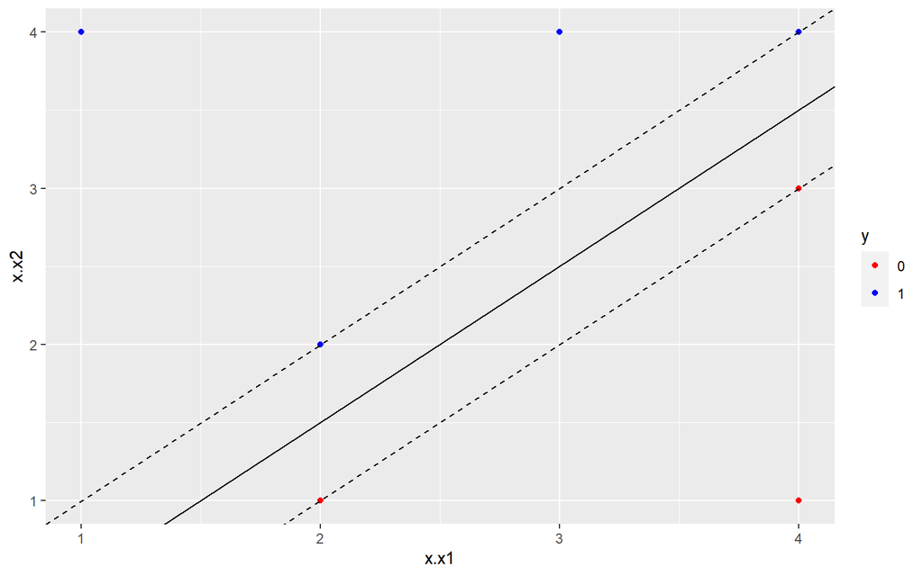

```r
#calculate slope and intercept of decision boundary from weight vector and svm model
w <- t(svmfit$coefs) %*% svmfit$SV
slope_1 <- -w[1]/w[2]
intercept_1 <- svmfit$rho/w[1]

#build scatter plot of training dataset
scatter_plot <- ggplot(data = dat, aes(x = x.x1, y = x.x2, color = y)) +
    geom_point() + scale_color_manual(values = c("red", "blue"))
#add decision boundary
plot_decision <- scatter_plot + geom_abline(slope = slope_1, intercept = intercept_1)
#add margin boundaries
plot_margins <- plot_decision +
 geom_abline(slope = slope_1, intercept = intercept_1 - 1/w[2], linetype = "dashed")+
 geom_abline(slope = slope_1, intercept = intercept_1 + 1/w[2], linetype = "dashed")
#display plot
plot_margins
```

```r
dis <- {}
for(i in 1:7){
  dis[i] <- abs(-2*x1[i]+2*x2[i]+1)/sqrt(2^2+2^2)
}
min(dis)
```

```
[1] 0.3535534
```

### **(4) (2 pts) What are the support vectors for the maximal margin classifier?**

From the plot we can see that (2,2), (4,4), (2,1) and (4,3) are support vectors.

## **2. (10 pts) Use the OJ data set, which is part of the ISLR package, to answer the following questions.**

### **(1) Create a training set containing a random sample of 900 observations, and a test set containing the remaining observations.**

```r
set.seed(123)
OJ.train <- sample(1:nrow(OJ), 900)
OJ.test <- OJ[-OJ.train,]
```

### **(2) Fit a tree to the training data, with Purchase as the response and the other variables as predictors. Use the summary function to produce summary statistics about the tree, and describe the results obtained. What is the training error rate? How many terminal nodes does the tree have?**

```r
tree.oj <- tree(Purchase~.,data = OJ, subset=OJ.train)
summary(tree.oj)
```

```
Classification tree:
tree(formula = Purchase ~ ., data = OJ, subset = OJ.train)
Variables actually used in tree construction:
[1] "LoyalCH"       "PriceDiff"     "PctDiscMM"     "ListPriceDiff"
Number of terminal nodes:  9
Residual mean deviance:  0.7519 = 670 / 891
Misclassification error rate: 0.16 = 144 / 900
```

The training error rate is 16%. There are nine terminal nodes in the tree.

### **(3) Type in the name of the tree object in order to get a detailed text output. Pick one of the terminal nodes, and interpret the information displayed.**

```r
tree.oj
```

```
node), split, n, deviance, yval, (yprob)
      * denotes terminal node

 1) root 900 1207.00 CH ( 0.60556 0.39444 )
   2) LoyalCH < 0.5036 398  473.00 MM ( 0.28141 0.71859 )
     4) LoyalCH < 0.276142 192  148.50 MM ( 0.13021 0.86979 )
       8) LoyalCH < 0.0356415 67   10.39 MM ( 0.01493 0.98507 ) *
       9) LoyalCH > 0.0356415 125  122.30 MM ( 0.19200 0.80800 ) *
     5) LoyalCH > 0.276142 206  280.60 MM ( 0.42233 0.57767 )
      10) PriceDiff < 0.05 89   92.30 MM ( 0.21348 0.78652 ) *
      11) PriceDiff > 0.05 117  159.10 CH ( 0.58120 0.41880 ) *
   3) LoyalCH > 0.5036 502  401.90 CH ( 0.86255 0.13745 )
     6) LoyalCH < 0.764572 206  239.10 CH ( 0.73301 0.26699 )
      12) PriceDiff < -0.165 34   41.19 MM ( 0.29412 0.70588 )
        24) PctDiscMM < 0.196197 12   15.28 CH ( 0.66667 0.33333 ) *
        25) PctDiscMM > 0.196197 22   13.40 MM ( 0.09091 0.90909 ) *
      13) PriceDiff > -0.165 172  162.30 CH ( 0.81977 0.18023 )
        26) ListPriceDiff < 0.135 29   40.17 CH ( 0.51724 0.48276 ) *
        27) ListPriceDiff > 0.135 143  104.30 CH ( 0.88112 0.11888 ) *
     7) LoyalCH > 0.764572 296  112.80 CH ( 0.95270 0.04730 ) *
```

The index 8) indicates that there are 67 observations that LoyalCH smaller than 0.0356415, and there deviance is 10.39, the predict probability of being MM is 0.98507 and the predict probability of being CH is 0.01493, so the prediction is MM.

### **(4) Create a plot of the tree, and interpret the results.**

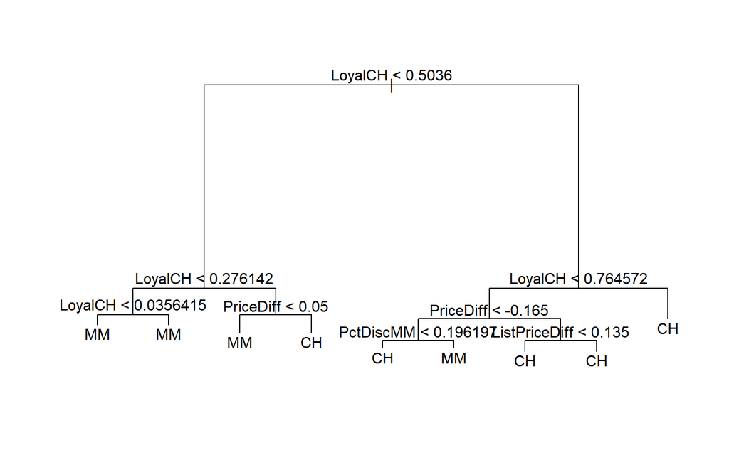

```r
plot(tree.oj)
text(tree.oj,pretty=0)
```

Following this plot, for each observation, make judgment at each node until get a terminal, then the text on this node is the prediction of this observation.

We may see that the most important indicator of “Purchase” appears to be “LoyalCH”, since the first branch differentiates the intensity of customer brand loyalty to CH. In fact, the top three nodes contain “LoyalCH”.

### **(5) Predict the response on the test data, and produce a confusion matrix comparing the test labels to the predicted test labels. What is the test error rate?**

```r
Purchase.test <- OJ$Purchase[-OJ.train]
tree.pred <- predict(tree.oj,OJ.test,type="class")  # predict the tree on the test dataset

table(tree.pred,Purchase.test)   # confusion matrix
```

```
         Purchase.test
tree.pred  CH  MM
       CH 102  23
       MM   6  39
```

```r
1-sum(tree.pred == Purchase.test)/170
```

```
[1] 0.1705882
```

the test error rate is 0.1705882.

### **(6) Apply the cv.tree() function to the training set in order to determine the optimal tree size.**

```r
set.seed(12345)
cv.oj <- cv.tree(tree.oj, FUN=prune.misclass )
```

### **(7) Produce a plot with tree size on the x-axis and cross-validated classification error rate on the y-axis.**

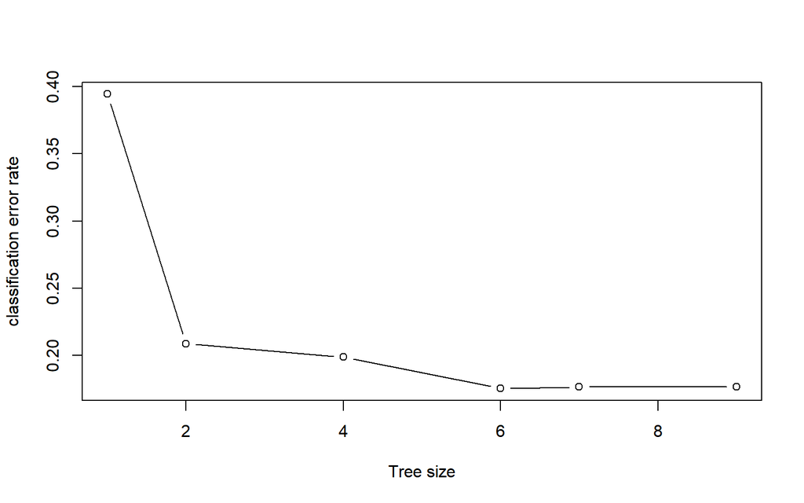

```r
plot(cv.oj$size, cv.oj$dev/900, type = "b", xlab = "Tree size", ylab = "classification error rate")
```

### **(8) Which tree size corresponds to the lowest cross-validated classification error rate?**

```r
cv.oj$size[which.min(cv.oj$dev)]
```

```
[1] 6
```

Tree size equal to 6 corresponds to the lowest cross-validated classification error rate

### **(9) Produce a pruned tree corresponding to the optimal tree size obtained using cross-validation.**

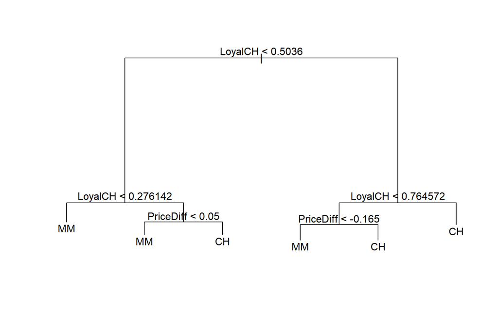

```r
prune.oj <- prune.misclass(tree.oj, best = cv.oj$size[which.min(cv.oj$dev)])
plot(prune.oj)
text(prune.oj, pretty = 0)
```

### **(10) Compare the training error rates between the pruned and unpruned trees. Which is higher?**

```r
summary(tree.oj)
```

```
Classification tree:
tree(formula = Purchase ~ ., data = OJ, subset = OJ.train)
Variables actually used in tree construction:
[1] "LoyalCH"       "PriceDiff"     "PctDiscMM"     "ListPriceDiff"
Number of terminal nodes:  9
Residual mean deviance:  0.7519 = 670 / 891
Misclassification error rate: 0.16 = 144 / 900
```

```r
summary(prune.oj)
```

```
Classification tree:
snip.tree(tree = tree.oj, nodes = c(4L, 13L, 12L))
Variables actually used in tree construction:
[1] "LoyalCH"   "PriceDiff"
Number of terminal nodes:  6
Residual mean deviance:  0.8011 = 716.2 / 894
Misclassification error rate: 0.1644 = 148 / 900
```

The misclassification error rate is slightly higher for the pruned tree (0.1644 vs 0.16).

### **(11) Compare the test error rates between the pruned and unpruned trees. Which is higher?**

```r
prune.pred <- predict(prune.oj, OJ.test, type = "class")
table(prune.pred, OJ.test$Purchase)
```

```
prune.pred  CH  MM
        CH 101  20
        MM   7  42
```

```r
1-sum(tree.pred == Purchase.test)/170
```

[output not shown]

## **3. (10 pts) Based on the Auto data set, predict whether a given car gets high or low gas mileage.**

### **(1) Create a binary variable that takes on a 1 for cars with gas mileage above the median, and a 0 for cars with gas mileage below the median.**

```r
var <- ifelse(Auto$mpg > median(Auto$mpg), 1, 0)
Auto$mpglevel <- as.factor(var)
```

### **(2) Fit a support vector classifier to the data with various values of cost, in order to predict whether a car gets high or low gas mileage. Report the cross-validation errors associated with different values of this parameter. Comment on your results.**

```r
set.seed(123)
tune.out <- tune(svm, mpglevel ~ .-name, data = Auto, kernel = "linear", ranges = list(cost = c(0.01, 0.1, 1, 10, 100, 1000)))
summary(tune.out)
```

```
Parameter tuning of 'svm':

- sampling method: 10-fold cross validation

- best parameters:
 cost
  100

- best performance: 0.002564103

- Detailed performance results:
   cost       error  dispersion
1 1e-02 0.076346154 0.039281909
2 1e-01 0.045897436 0.033611865
3 1e+00 0.010256410 0.013240969
4 1e+01 0.007692308 0.012385792
5 1e+02 0.002564103 0.008108404
6 1e+03 0.002564103 0.008108404
```

```r
bestmod <- tune.out$best.model
bestmod %>% summary
```

```
Call:
best.tune(method = svm, train.x = mpglevel ~ . - name, data = Auto,
    ranges = list(cost = c(0.01, 0.1, 1, 10, 100, 1000)), kernel = "linear")


Parameters:
   SVM-Type:  C-classification
 SVM-Kernel:  linear
       cost:  100

Number of Support Vectors:  10

 ( 4 6 )


Number of Classes:  2

Levels:
 0 1
```

The model with lowest value of cross validation would be when cost = 100, number of Support vectors is 10.

### **(3) Now repeat (2), this time using SVMs with radial and polynomial basis kernels, with different values of gamma and degree and cost. Comment on your results.**

```r
set.seed(123)
tune.out <- tune(svm, mpglevel ~ .-name, data = Auto, kernel = "polynomial", ranges = list(cost = c(0.01, 0.1, 1, 5, 10, 100), degree = c(2, 3, 4)))
summary(tune.out)
```

```
Parameter tuning of 'svm':

- sampling method: 10-fold cross validation

- best parameters:
 cost degree
  100      3

- best performance: 0.03051282

- Detailed performance results:
    cost degree      error dispersion
1  1e-02      2 0.49711538 0.12333531
2  1e-01      2 0.27801282 0.08475882
3  1e+00      2 0.23448718 0.08056536
4  5e+00      2 0.18076923 0.07510251
5  1e+01      2 0.19608974 0.08315368
6  1e+02      2 0.18846154 0.06593118
7  1e-02      3 0.25762821 0.08224273
8  1e-01      3 0.15044872 0.07895815
9  1e+00      3 0.06365385 0.03640019
10 5e+00      3 0.04076923 0.02733072
11 1e+01      3 0.03564103 0.02983537
12 1e+02      3 0.03051282 0.02316421
13 1e-02      4 0.38275641 0.10466092
14 1e-01      4 0.27551282 0.08842427
15 1e+00      4 0.21397436 0.06798284
16 5e+00      4 0.17814103 0.06954821
17 1e+01      4 0.16788462 0.07058042
18 1e+02      4 0.10929487 0.04814596
```

For a polynomial kernel, the lowest cross-validation error is obtained for a degree of 3 and a cost of 100.

```r
set.seed(123)
tune.out <- tune(svm, mpglevel ~ .-name, data = Auto, kernel = "radial", ranges = list(cost = c(0.01, 0.1, 1, 5, 10, 100), gamma = c(0.01, 0.1, 1, 5, 10, 100)))
summary(tune.out)
```

```
Parameter tuning of 'svm':

- sampling method: 10-fold cross validation

- best parameters:
 cost gamma
  100  0.01

- best performance: 0.01282051

- Detailed performance results:
    cost gamma      error dispersion
1  1e-02  0.01 0.58173077 0.04740051
2  1e-01  0.01 0.08916667 0.04345384
3  1e+00  0.01 0.07378205 0.04185248
4  5e+00  0.01 0.04589744 0.03136327
5  1e+01  0.01 0.02794872 0.02786017
6  1e+02  0.01 0.01282051 0.01351401
7  1e-02  0.10 0.11711538 0.07860928
8  1e-01  0.10 0.07634615 0.03928191
9  1e+00  0.10 0.04583333 0.02886633
10 5e+00  0.10 0.02294872 0.00806776
11 1e+01  0.10 0.02044872 0.01619554
12 1e+02  0.10 0.02557692 0.01709522
13 1e-02  1.00 0.58173077 0.04740051
14 1e-01  1.00 0.09429487 0.04146670
15 1e+00  1.00 0.05333333 0.04166261
16 5e+00  1.00 0.05089744 0.03945905
17 1e+01  1.00 0.05608974 0.03118084
18 1e+02  1.00 0.05608974 0.03118084
 [ reached 'max' / getOption("max.print") -- omitted 18 rows ]
```

For a radial kernel, the lowest cross-validation error is obtained for a gamma of 0.01 and a cost of 100.

## **4. (10 pts) Use the Boston data set in the MASS package to predict the median value of owner-occupied homes (in $1000’s) by training the neural networks. Employ all available predictors in the data.**

### **(1) When training your network, vary the number of hidden layer from 1 to 10 but keep the number of neurons in each layer at 5. Find the best network that has the lowest MSE. Remember to apply min-max scale to the data before fitting the network.Also split the data to 75% training and 25% test data.**

```r
## Scale Boston for neural network
max = apply(Boston , 2 , max)
min = apply(Boston, 2 , min)
scaled = as.data.frame(scale(Boston, center = min, scale = max - min))

samplesize = 0.75 * nrow(Boston)
set.seed(123)
index = sample(nrow(Boston),size = samplesize)

# creating training and test set
trainNN = scaled[index,]
testNN = scaled[-index,]
datatest = Boston[-index,]
```

```r
RMSE.NN <- {}
for(i in 1:10){
    set.seed(123)
    NN = neuralnet(medv ~ ., trainNN, hidden = rep(5,i) , linear.output = T )
    predict_testNN = compute(NN,testNN[,c(1:13)])
    predict_testNN = (predict_testNN$net.result*(max(Boston$medv)-min(Boston$medv)))+min(Boston$medv)

    RMSE.NN[i] <- (sum((datatest$medv - predict_testNN)^2)/nrow(datatest))^0.5
}
which.min(RMSE.NN)
```

```
[1] 4
```

The network that has 4 hidden layers has the lowest MSE.

### **(2) Do 10-fold cross validation on the network determined in (1) and report the mean CV error.**

```r
k=10
set.seed(123)

folds=sample(1:k,nrow(scaled),replace=TRUE)
RMSE.cv <- {}

for(i in 1:10){
  trainset=scaled[folds!=i,]
  testset=scaled[folds==i,]
  datatest = Boston[folds==i,]
  NN = neuralnet(medv ~ ., trainset, hidden = rep(5,which.min(RMSE.NN)) , linear.output = T )
  predict_testNN = compute(NN,testset[,c(1:13)])
  predict_testNN = (predict_testNN$net.result*(max(Boston$medv)-min(Boston$medv)))+min(Boston$medv)

  RMSE.cv[i] <- (sum((datatest$medv - predict_testNN)^2)/nrow(datatest))^0.5
}

mean(RMSE.cv)
```

```
[1] 3.059198
```

The mean CV error in my network is 3.059198.